# Data Analysis Project

Congratulations on getting a job as a data scientist at Paramount Pictures! Please see the Data Analysis Project for your assignment. Below you will find the files that you will need.

Your boss has just acquired data about how much audiences and critics like movies as well as numerous other variables about the movies. This dataset is provided below, and it includes information from Rotten Tomatoes and IMDB for a random sample of movies.

She is interested in learning what attributes make a movie popular. She is also interested in learning something new about movies. She wants you team to figure it all out.

As part of this project you will complete exploratory data analysis (EDA), modeling, and prediction.

The specific modeling task you need to complete is as follows: Develop a Bayesian regression model to predict audience_score from the following explanatory variables. Note that some of these variables are in the original dataset provided, and others are new variables you will need to construct in the data manipulation section using the mutate function in dplyr:

- feature_film: “yes” if title_type is Feature Film, “no” otherwise
- drama: “yes” if genre is Drama, “no” otherwise
- runtime
- mpaa_rating_R: “yes” if mpaa_rating is R, “no” otherwise
- thtr_rel_year
- oscar_season: “yes” if movie is released in November, October, or December (based on thtr_rel_month), “no” otherwise
- summer_season: “yes” if movie is released in May, June, July, or August (based on thtr_rel_month), “no” otherwise
- imdb_rating
- imdb_num_votes
- critics_score
- best_pic_nom
- best_pic_win
- best_actor_win
- best_actress_win
- best_dir_win
- top200_box

All analysis must be completed using the R programming language via RStudio, and your write up must be an R Markdown document. To help you get started we provide a template Rmd file below (see Rmd template in the Required files section below). Download this file, and fill in each section.

NOTE: If you have previously completed the Course 3 in the Statistics with R Specialization (Linear Regression and Modeling) you should be familiar with this dataset. While the dataset is the same, the tasks you are asked to carry out for this project are different.

IMPORTANT: Analyses completed using software other than R, or not written up using R Markdown, will receive a 0 on the project regardless of their content.

Your project will consist of 6 parts:

1. Data
2. Data manipulation
3. EDA
4. Modeling
5. Prediction
6. Conclusion

## Setup

### Load packages

```r
library(ggplot2)
library(dplyr)
library(statsr)
library(BAS)
```

### Load data

Make sure your data and R Markdown files are in the same directory. When loaded your data file will be called `movies`. Delete this note when before you submit your work.

```r
load("movies.Rdata")
```

## Part 1: Data

(2 points) Describe how the observations in the sample are collected, and the implications of this data collection method on the scope of inference (generalizability / causality).

As mentioned, the data set is comprised of $651$ randomly sampled movies (produced and released before $2016$). Also, from the below summary of the data, it can be seen the dataset is quite representative (diverse in the sense that it contains many possible combination of values for each of the explanatory variables) of the population, hence likely to be *generalizable* (assuming that the relation between predictor and response does not change much after $2016$).

But, there is no controlled experiment / random assignment done and the covariates of the linear regression are not chosen with a controlled experiment, hence it is likely to imply correlation between response and the predictors and *not causality*.

Also, since the underlying movies dataset from which the samples were chosen is likely not randomly sampled from the entire population of movies, there can be selection bias (e.g., voluntary bias).

```r
library(GGally)
#head(movies)
names(movies)
```

```
##  [1] "title"            "title_type"       "genre"            "runtime"
##  [5] "mpaa_rating"      "studio"           "thtr_rel_year"    "thtr_rel_month"
##  [9] "thtr_rel_day"     "dvd_rel_year"     "dvd_rel_month"    "dvd_rel_day"
## [13] "imdb_rating"      "imdb_num_votes"   "critics_rating"   "critics_score"
## [17] "audience_rating"  "audience_score"   "best_pic_nom"     "best_pic_win"
## [21] "best_actor_win"   "best_actress_win" "best_dir_win"     "top200_box"
## [25] "director"         "actor1"           "actor2"           "actor3"
## [29] "actor4"           "actor5"           "imdb_url"         "rt_url"
```

```r
summary(movies[,c(2:5, 7:8, 10:23)])
```

```
##         title_type                 genre        runtime       mpaa_rating
##  Documentary : 55   Drama             :305   Min.   : 39.0   G      : 19
##  Feature Film:591   Comedy            : 87   1st Qu.: 92.0   NC-17  :  2
##  TV Movie    :  5   Action & Adventure: 65   Median :103.0   PG     :118
##                     Mystery & Suspense: 59   Mean   :105.8   PG-13  :133
##                     Documentary       : 52   3rd Qu.:115.8   R      :329
##                     Horror            : 23   Max.   :267.0   Unrated: 50
##                     (Other)           : 60   NA's   :1
##  thtr_rel_year  thtr_rel_month   dvd_rel_year  dvd_rel_month     dvd_rel_day
##  Min.   :1970   Min.   : 1.00   Min.   :1991   Min.   : 1.000   Min.   : 1.00
##  1st Qu.:1990   1st Qu.: 4.00   1st Qu.:2001   1st Qu.: 3.000   1st Qu.: 7.00
##  Median :2000   Median : 7.00   Median :2004   Median : 6.000   Median :15.00
##  Mean   :1998   Mean   : 6.74   Mean   :2004   Mean   : 6.333   Mean   :15.01
##  3rd Qu.:2007   3rd Qu.:10.00   3rd Qu.:2008   3rd Qu.: 9.000   3rd Qu.:23.00
##  Max.   :2014   Max.   :12.00   Max.   :2015   Max.   :12.000   Max.   :31.00
##                                 NA's   :8      NA's   :8        NA's   :8
##   imdb_rating    imdb_num_votes           critics_rating critics_score
##  Min.   :1.900   Min.   :   180   Certified Fresh:135    Min.   :  1.00
##  1st Qu.:5.900   1st Qu.:  4546   Fresh          :209    1st Qu.: 33.00
##  Median :6.600   Median : 15116   Rotten         :307    Median : 61.00
##  Mean   :6.493   Mean   : 57533                          Mean   : 57.69
##  3rd Qu.:7.300   3rd Qu.: 58301                          3rd Qu.: 83.00
##  Max.   :9.000   Max.   :893008                          Max.   :100.00
##
##  audience_rating audience_score  best_pic_nom best_pic_win best_actor_win
##  Spilled:275     Min.   :11.00   no :629      no :644      no :558
##  Upright:376     1st Qu.:46.00   yes: 22      yes:  7      yes: 93
##                  Median :65.00
##                  Mean   :62.36
##                  3rd Qu.:80.00
##                  Max.   :97.00
##
##  best_actress_win best_dir_win
##  no :579          no :608
##  yes: 72          yes: 43
##
##
##
##
##
```

From the above summary, we can see that out of $651$ movies only $22$ got best picture nominations for the oscar, the mean IMDB rating in the sample dataset is around $6.5$, the average critics score is around $57.7$, whereas the average audience score is around $62.4$.

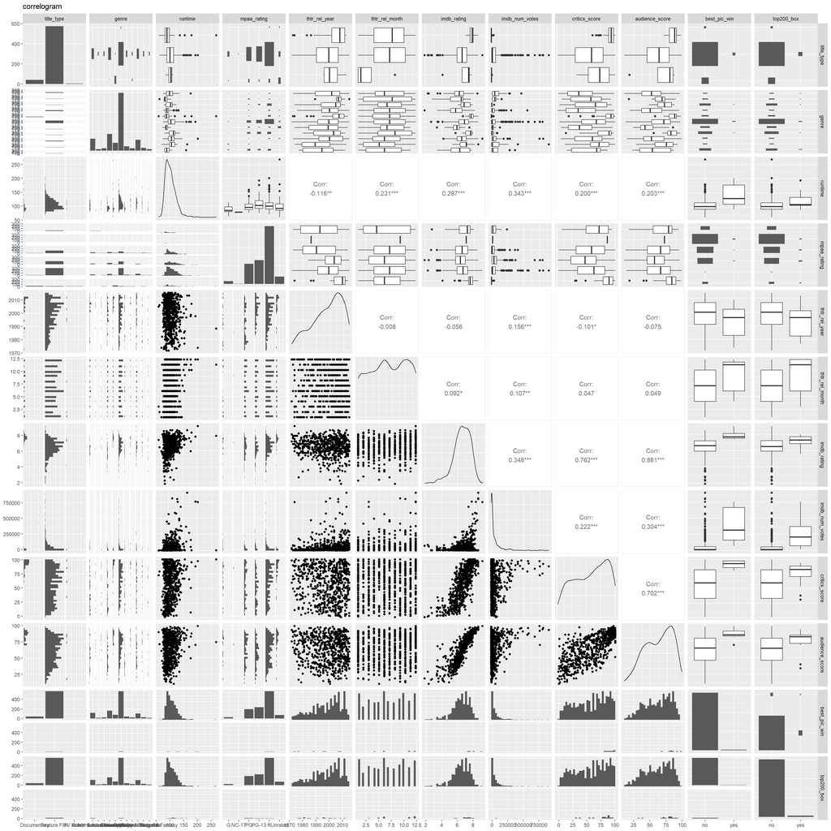

```r
p <- ggpairs(na.omit(movies), columns=c("title_type", "genre", "runtime", "mpaa_rating", "thtr_rel_year",
                                        "thtr_rel_month", "imdb_rating", "imdb_num_votes", "critics_score",
                                        "audience_score", "best_pic_win", "top200_box"),
             title="correlogram",
             progress = FALSE)
suppressMessages(print(p))
```

The above figure visualizes the distribution of the variables and the mutual association between any two pairs chosen. For example, observe that `runtime` is right skewed, whereas `imdb_rating` and `audiance_score` variables are left skewed. The variables `imdb_rating and the`critics_score`have positive correlations with the response`audience_score` etc.

## Part 2: Data manipulation

(10 points) Create new variables using the mutate function in the dplyr package following these guidelines:

Create new variable based on `title_type`: New variable should be called `feature_film` with levels yes (movies that are feature films) and no (2 pt)

Create new variable based on `genre`: New variable should be called `drama` with levels yes (movies that are dramas) and no (2 pt)

Create new variable based on `mpaa_rating`: New variable should be called `mpaa_rating_R` with levels yes (movies that are R rated) and no (2 pt)

Create two new variables based on `thtr_rel_month`:

```
New variable called `oscar_season` with levels yes (if movie is released in November, October, or December) and no (2 pt)

New variable called `summer_season` with levels yes (if movie is released in May, June, July, or August) and no (2 pt)
```

Let’s use the following code to create the new variables.

```r
movies <- movies %>% mutate(feature_film = ifelse(title_type == 'Feature Film', 'yes', 'no'),
                            drama = ifelse(genre == 'Drama', 'yes', 'no'),
                            mpaa_rating_R = ifelse(mpaa_rating == 'R', 'yes', 'no'),
                            oscar_season = ifelse(thtr_rel_month >= 10, 'yes', 'no'),
                            summer_season = ifelse(thtr_rel_month %in% 5:8, 'yes', 'no'))
names(movies)
```

```
##  [1] "title"            "title_type"       "genre"            "runtime"
##  [5] "mpaa_rating"      "studio"           "thtr_rel_year"    "thtr_rel_month"
##  [9] "thtr_rel_day"     "dvd_rel_year"     "dvd_rel_month"    "dvd_rel_day"
## [13] "imdb_rating"      "imdb_num_votes"   "critics_rating"   "critics_score"
## [17] "audience_rating"  "audience_score"   "best_pic_nom"     "best_pic_win"
## [21] "best_actor_win"   "best_actress_win" "best_dir_win"     "top200_box"
## [25] "director"         "actor1"           "actor2"           "actor3"
## [29] "actor4"           "actor5"           "imdb_url"         "rt_url"
## [33] "feature_film"     "drama"            "mpaa_rating_R"    "oscar_season"
## [37] "summer_season"
```

```r
head(movies[c('feature_film', 'drama', 'mpaa_rating_R', 'oscar_season', 'summer_season')])
```

```
## # A tibble: 6 x 5
##   feature_film drama mpaa_rating_R oscar_season summer_season
##   <chr>        <chr> <chr>         <chr>        <chr>
## 1 yes          yes   yes           no           no
## 2 yes          yes   no            no           no
## 3 yes          no    yes           no           yes
## 4 yes          yes   no            yes          no
## 5 yes          no    yes           no           no
## 6 no           no    no            no           no
```

As can be seen from above, the new variables are added to the tibble, as needed.

## Part 3: Exploratory data analysis

(9 points) Perform exploratory data analysis (EDA) of the relationship between audience_score and the new variables constructed in the previous part. Your EDA should contain numerical summaries and visualizations. This might mean you initially create a lot more visualizations and summary statistics than what you finally choose to include in your paper. Each R output and plot should be accompanied by a brief interpretation.

The following code snippet analyzes the relationship between the `audience_score` and `feature_film`, with exploratory visualization.

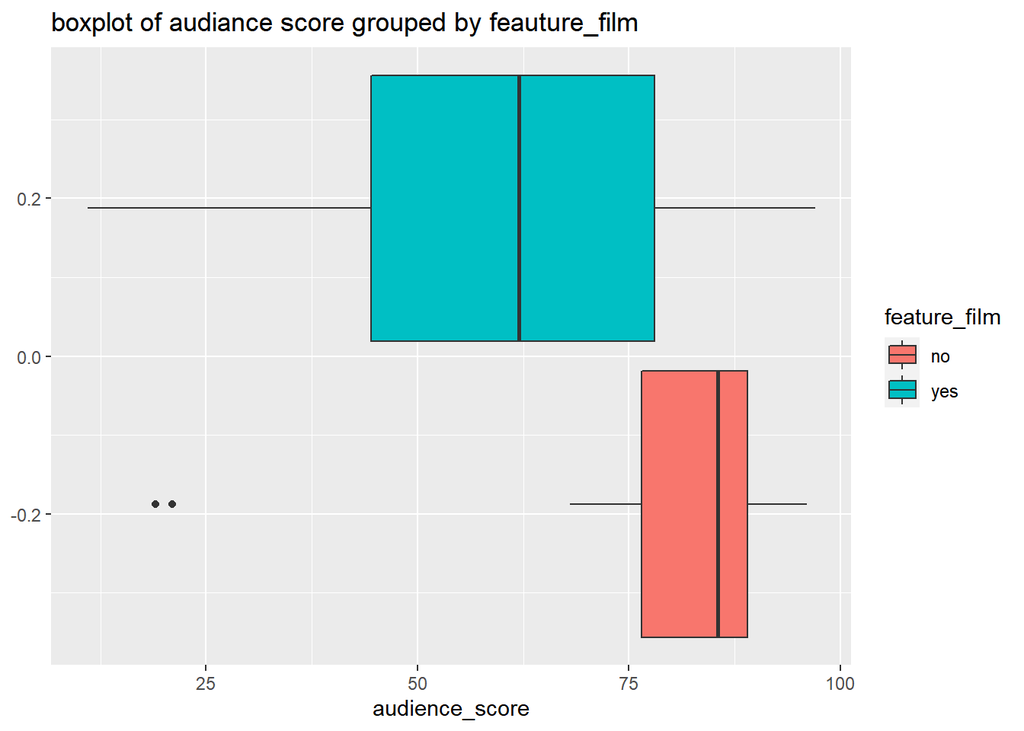

```r
ggplot(movies, aes(audience_score, group=feature_film, fill=feature_film)) +
  geom_boxplot() + ggtitle('boxplot of audiance score grouped by feauture_film')
```

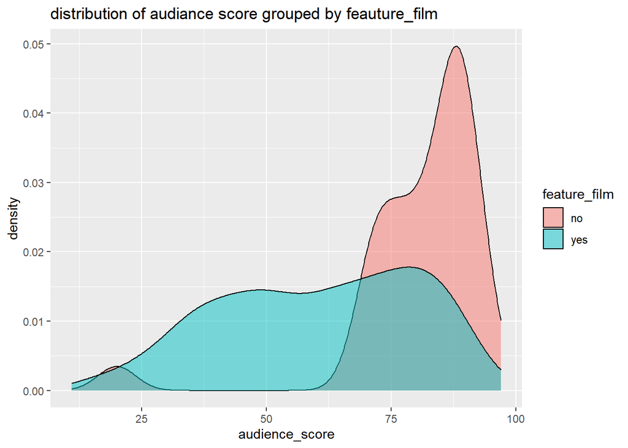

```r
ggplot(movies, aes(audience_score, group=feature_film, fill=feature_film)) +
  geom_density(alpha=0.5) + ggtitle('distribution of audiance score grouped by feauture_film')
```

```r
movies %>% group_by(feature_film) %>%
  summarize(score_Min = min(audience_score),
             score_Q1 = quantile(audience_score, .25),
             score_mean = mean(audience_score),
             score_median = median(audience_score),
             score_Q3 = quantile(audience_score, .75),
             score_Max = max(audience_score))
```

```
## # A tibble: 2 x 7
##   feature_film score_Min score_Q1 score_mean score_median score_Q3 score_Max
## * <chr>            <dbl>    <dbl>      <dbl>        <dbl>    <dbl>     <dbl>
## 1 no                  19     76.5       81.0         85.5       89        96
## 2 yes                 11     44.5       60.5         62         78        97
```

Similarly, the following code snippet analyzes the relationship between the `audience_score` and `drama`, with exploratory visualization.

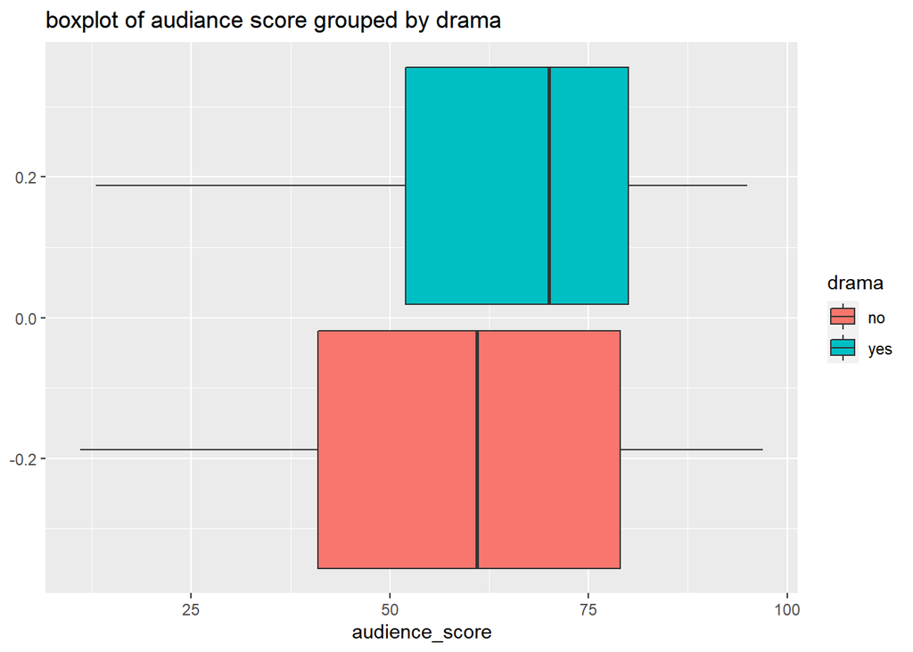

```r
ggplot(movies, aes(audience_score, group=drama, fill=drama)) +
  geom_boxplot() + ggtitle('boxplot of audiance score grouped by drama')
```

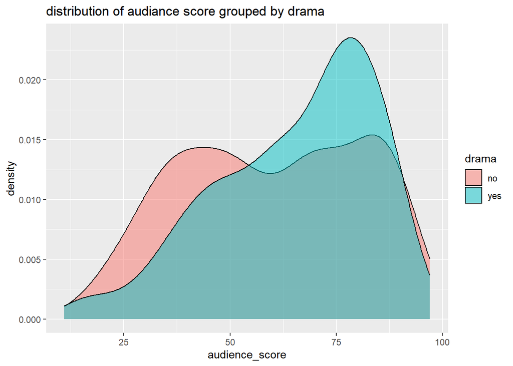

```r
ggplot(movies, aes(audience_score, group=drama, fill=drama)) +
  geom_density(alpha=0.5) + ggtitle('distribution of audiance score grouped by drama')
```

```r
movies %>% group_by(drama) %>%
  summarize(score_Min = min(audience_score),
             score_Q1 = quantile(audience_score, .25),
             score_mean = mean(audience_score),
             score_median = median(audience_score),
             score_Q3 = quantile(audience_score, .75),
             score_Max = max(audience_score))
```

```
## # A tibble: 2 x 7
##   drama score_Min score_Q1 score_mean score_median score_Q3 score_Max
## * <chr>     <dbl>    <dbl>      <dbl>        <dbl>    <dbl>     <dbl>
## 1 no           11       41       59.7           61       79        97
## 2 yes          13       52       65.3           70       80        95
```

Next, the following code snippet analyzes the relationship between the `audience_score` and `mpaa_rating_R`, with exploratory visualization.

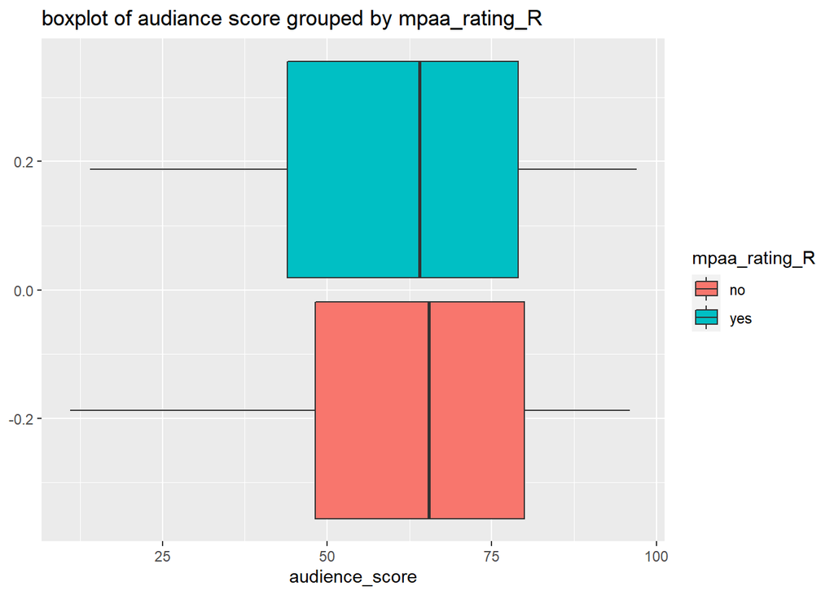

```r
ggplot(movies, aes(audience_score, group=mpaa_rating_R, fill=mpaa_rating_R)) +
  geom_boxplot() + ggtitle('boxplot of audiance score grouped by mpaa_rating_R')
```

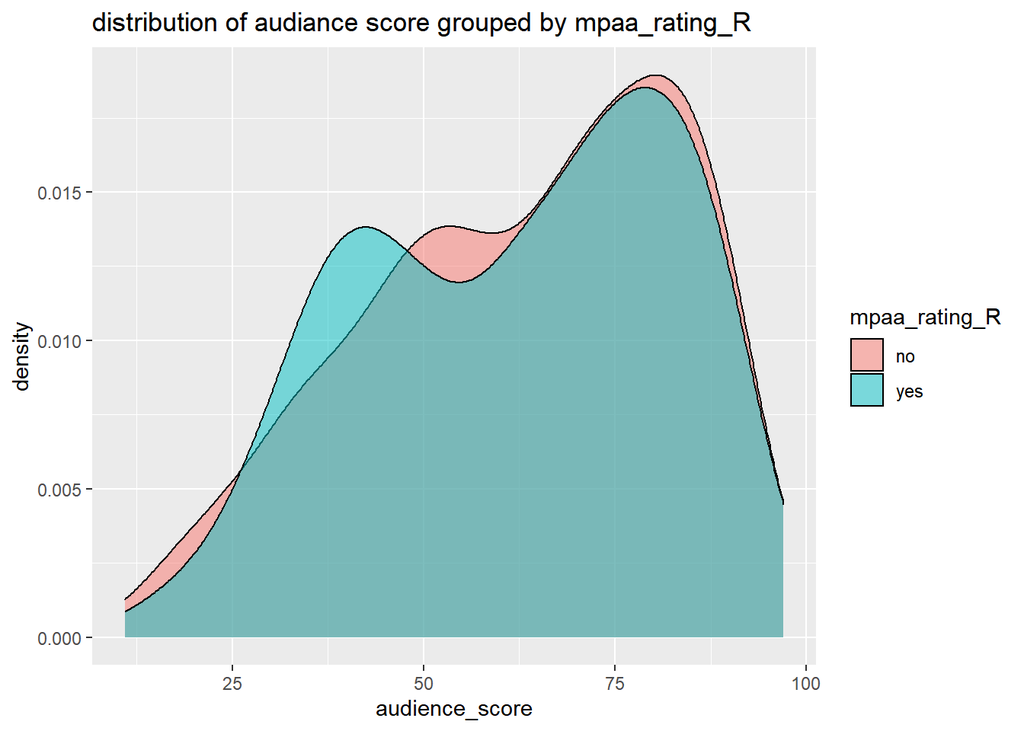

```r
ggplot(movies, aes(audience_score, group=mpaa_rating_R, fill=mpaa_rating_R)) +
  geom_density(alpha=0.5) +  ggtitle('distribution of audiance score grouped by mpaa_rating_R')
```

```r
movies %>% group_by(mpaa_rating_R) %>%
  summarize(score_Min = min(audience_score),
             score_Q1 = quantile(audience_score, .25),
             score_mean = mean(audience_score),
             score_median = median(audience_score),
             score_Q3 = quantile(audience_score, .75),
             score_Max = max(audience_score))
```

```
## # A tibble: 2 x 7
##   mpaa_rating_R score_Min score_Q1 score_mean score_median score_Q3 score_Max
## * <chr>             <dbl>    <dbl>      <dbl>        <dbl>    <dbl>     <dbl>
## 1 no                   11     48.2       62.7         65.5       80        96
## 2 yes                  14     44         62.0         64         79        97
```

## Part 4: Modeling

(15 points) Develop a Bayesian regression model to predict `audience_score` from the following explanatory variables. Note that some of these variables are in the original dataset provided, and others are new variables you constructed earlier:`feature_film`,`drama`, `runtime`, `mpaa_rating_R`, `thtr_rel_year`, `oscar_season`, `summer_season`, `imdb_rating`, `imdb_num_votes`, `critics_score`, `best_pic_nom`, `best_pic_win`, `best_actor_win`, `best_actress_win`, `best_dir_win`, `top200_box`. Complete Bayesian model selection and report the final model. Also perform model diagnostics and interpret coefficients of your final model in context of the data.

Let’s first create a reduced dataset with the relevant feature variables as mentioned and then clean the data by removing `NA` values. Then let;s create a Bayesian linear regression model, with `BIC` prior on the coefficients and a `uniform` model prior (equal probabilities to all models), using the following `R` code snippet.

```r
movies_reduced <- movies[c('feature_film', 'drama', 'runtime', 'mpaa_rating_R', 'thtr_rel_year',
                           'oscar_season', 'summer_season', 'imdb_rating', 'imdb_num_votes',
                           'critics_score', 'best_pic_nom', 'best_pic_win', 'best_actor_win',
                           'best_actress_win', 'best_dir_win', 'top200_box', 'audience_score')]

head(movies_reduced)
```

```
## # A tibble: 6 x 17
##   feature_film drama runtime mpaa_rating_R thtr_rel_year oscar_season
##   <chr>        <chr>   <dbl> <chr>                 <dbl> <chr>
## 1 yes          yes        80 yes                    2013 no
## 2 yes          yes       101 no                     2001 no
## 3 yes          no         84 yes                    1996 no
## 4 yes          yes       139 no                     1993 yes
## 5 yes          no         90 yes                    2004 no
## 6 no           no         78 no                     2009 no
## # ... with 11 more variables: summer_season <chr>, imdb_rating <dbl>,
## #   imdb_num_votes <int>, critics_score <dbl>, best_pic_nom <fct>,
## #   best_pic_win <fct>, best_actor_win <fct>, best_actress_win <fct>,
## #   best_dir_win <fct>, top200_box <fct>, audience_score <dbl>
```

```r
dim(movies_reduced)
```

```
## [1] 651  17
```

```r
movies_no_na <- na.omit(movies_reduced)
dim(movies_no_na)
```

```
## [1] 650  17
```

```r
# Fit the model using Bayesian linear regression, `bas.lm` function in the `BAS` package
bma_lscore <- bas.lm(audience_score ~ .-audience_score, data = movies_no_na,
                   prior = "BIC",
                   modelprior = uniform())

# Print out the marginal posterior inclusion probabilities for each variable
bma_lscore
```

```
##
## Call:
## bas.lm(formula = audience_score ~ . - audience_score, data = movies_no_na,
##     prior = "BIC", modelprior = uniform())
##
##
##  Marginal Posterior Inclusion Probabilities:
##           Intercept      feature_filmyes             dramayes
##             1.00000              0.06537              0.04320
##             runtime     mpaa_rating_Ryes        thtr_rel_year
##             0.46971              0.19984              0.09069
##     oscar_seasonyes     summer_seasonyes          imdb_rating
##             0.07506              0.08042              1.00000
##      imdb_num_votes        critics_score      best_pic_nomyes
##             0.05774              0.88855              0.13119
##     best_pic_winyes    best_actor_winyes  best_actress_winyes
##             0.03985              0.14435              0.14128
##     best_dir_winyes        top200_boxyes
##             0.06694              0.04762
```

```r
summary(bma_lscore)
```

```
##                     P(B != 0 | Y)    model 1       model 2       model 3
## Intercept              1.00000000     1.0000     1.0000000     1.0000000
## feature_filmyes        0.06536947     0.0000     0.0000000     0.0000000
## dramayes               0.04319833     0.0000     0.0000000     0.0000000
## runtime                0.46971477     1.0000     0.0000000     0.0000000
## mpaa_rating_Ryes       0.19984016     0.0000     0.0000000     0.0000000
## thtr_rel_year          0.09068970     0.0000     0.0000000     0.0000000
## oscar_seasonyes        0.07505684     0.0000     0.0000000     0.0000000
## summer_seasonyes       0.08042023     0.0000     0.0000000     0.0000000
## imdb_rating            1.00000000     1.0000     1.0000000     1.0000000
## imdb_num_votes         0.05773502     0.0000     0.0000000     0.0000000
## critics_score          0.88855056     1.0000     1.0000000     1.0000000
## best_pic_nomyes        0.13119140     0.0000     0.0000000     0.0000000
## best_pic_winyes        0.03984766     0.0000     0.0000000     0.0000000
## best_actor_winyes      0.14434896     0.0000     0.0000000     1.0000000
## best_actress_winyes    0.14128087     0.0000     0.0000000     0.0000000
## best_dir_winyes        0.06693898     0.0000     0.0000000     0.0000000
## top200_boxyes          0.04762234     0.0000     0.0000000     0.0000000
## BF                             NA     1.0000     0.9968489     0.2543185
## PostProbs                      NA     0.1297     0.1293000     0.0330000
## R2                             NA     0.7549     0.7525000     0.7539000
## dim                            NA     4.0000     3.0000000     4.0000000
## logmarg                        NA -3615.2791 -3615.2822108 -3616.6482224
##                           model 4       model 5
## Intercept               1.0000000     1.0000000
## feature_filmyes         0.0000000     0.0000000
## dramayes                0.0000000     0.0000000
## runtime                 0.0000000     1.0000000
## mpaa_rating_Ryes        1.0000000     1.0000000
## thtr_rel_year           0.0000000     0.0000000
## oscar_seasonyes         0.0000000     0.0000000
## summer_seasonyes        0.0000000     0.0000000
## imdb_rating             1.0000000     1.0000000
## imdb_num_votes          0.0000000     0.0000000
## critics_score           1.0000000     1.0000000
## best_pic_nomyes         0.0000000     0.0000000
## best_pic_winyes         0.0000000     0.0000000
## best_actor_winyes       0.0000000     0.0000000
## best_actress_winyes     0.0000000     0.0000000
## best_dir_winyes         0.0000000     0.0000000
## top200_boxyes           0.0000000     0.0000000
## BF                      0.2521327     0.2391994
## PostProbs               0.0327000     0.0310000
## R2                      0.7539000     0.7563000
## dim                     4.0000000     5.0000000
## logmarg             -3616.6568544 -3616.7095127
```

Printing the model object and the summary function gives us both the posterior model inclusion probability for each variable and the 5 most probable models. For example, the posterior probability that `runtime` is included in the model is $0.46971$, as can be seen from above output. Further, the most likely model, which has the highest posterior probability of $0.1297$, includes an `intercept`, `runtime`, `imdb_rating` and `critics_score` (shown in the figure with title *Model Ranking*, where the most likely model, i.e., model 1 corresponds to the leftmost model), with $R^2$ of $0.7549$. Also the above table shows the *Bayes factor*s for each model to the highest probability model (hence its Bayes factor is $1$). To see beyond the first five models, we can represent the collection of the models via an image plot. By default this shows the top $20$ models (`?image.bas`).

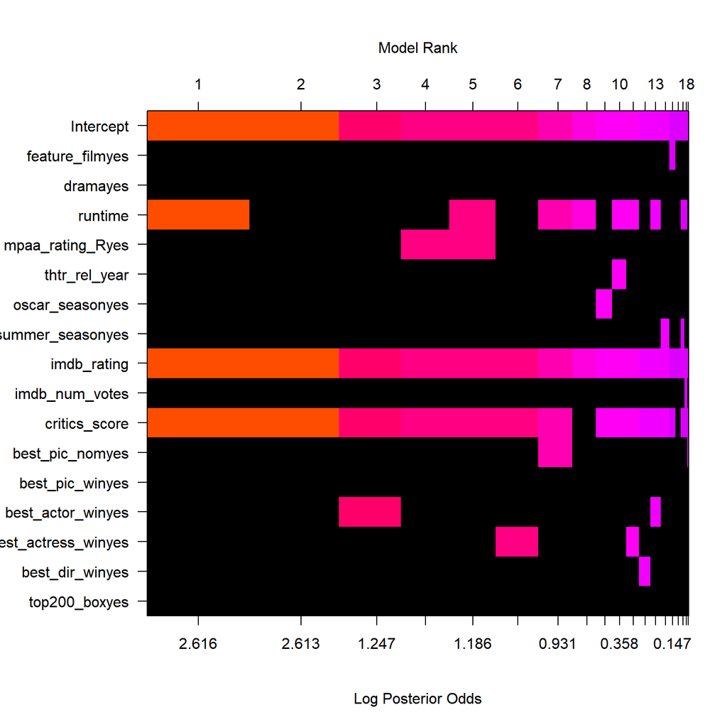

```r
image(bma_lscore, rotate = F)
```

This above image has rows that correspond to each of the variables and intercept, with labels for the variables on the y-axis. The x-axis corresponds to the possible models. These are sorted by their posterior probability from best at the left to worst at the right with the rank on the top x-axis. Models that are the same color have similar log Bayes factors which allows us to view models that are clustered together that have Bayes Factors where the differences are not *worth a bare mention*. This plot indicates that the `imdb_rating` and the `critics_score` enter the almost all the models together, and is an indication of the high correlation between the two variables. But the `best_actor_win_yes` and `best_actress_win_yes` have low correlation, as can be verified using the code snippet below.

```r
cor(movies_no_na$imdb_rating, movies_no_na$critics_score)
```

```
## [1] 0.7647832
```

```r
cor(movies_no_na$best_actor_win == 'yes', movies_no_na$best_actress_win == 'yes')
```

```
## [1] 0.1357741
```

While a posterior probability of $0.1297$ for model 1 (the one with the highest posteriror probability) sounds small, it is much larger than the uniform prior probability assigned to it, since there are $2^{16}$ possible models. The following figure shows how the posterior probabilities for the top $25$ models got increased from the uniform prior probabilities.

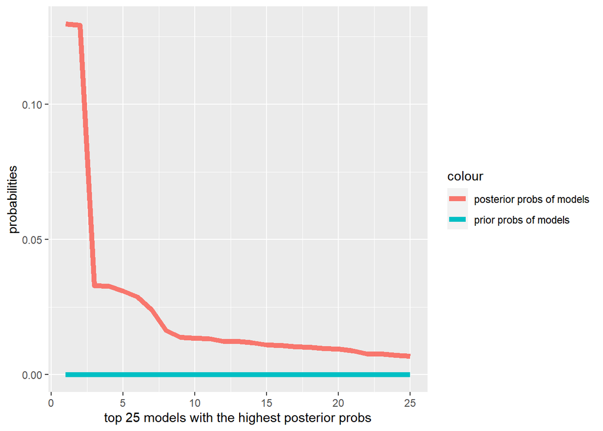

```r
k <- 25
indices <- sort(bma_lscore$postprobs, decreasing = TRUE, index.return=TRUE)$ix[1:k]
ggplot() +
  geom_line(aes(1:k, bma_lscore$priorprobs[indices]/2^16, color='prior probs of models'), stat='identity', lwd=2) +
  geom_line(aes(1:k, bma_lscore$postprobs[indices], color='posterior probs of models'), stat='identity', lwd=2) +
  xlab(sprintf('top %d models with the highest posterior probs', k)) + ylab('probabilities')
```

#### Interpreting the coefficients

It is also possible to visualize the posterior distribution of the coefficients under the model averaging approach. Plots of the posterior distributions averaging over all of the models can be obtained using the plot method for the `bas` coefficient object. Let’s graph the posterior distribution of the coefficients of `runtime` and `imdb_rating` below. Note that the subset parameter dictates which variable is plotted.

```r
# Obtain the coefficients from the model `bma_lscore`
coef_lscore <- coefficients(bma_lscore)
coef_lscore
```

```
##
##  Marginal Posterior Summaries of Coefficients:
##
##  Using  BMA
##
##  Based on the top  65536 models
##                      post mean   post SD     post p(B != 0)
## Intercept             6.235e+01   3.946e-01   1.000e+00
## feature_filmyes      -1.047e-01   5.643e-01   6.537e-02
## dramayes              1.604e-02   1.939e-01   4.320e-02
## runtime              -2.568e-02   3.118e-02   4.697e-01
## mpaa_rating_Ryes     -3.036e-01   7.032e-01   1.998e-01
## thtr_rel_year        -4.533e-03   1.819e-02   9.069e-02
## oscar_seasonyes      -8.035e-02   3.773e-01   7.506e-02
## summer_seasonyes      8.705e-02   3.831e-01   8.042e-02
## imdb_rating           1.498e+01   7.310e-01   1.000e+00
## imdb_num_votes        2.081e-07   1.313e-06   5.774e-02
## critics_score         6.297e-02   3.028e-02   8.886e-01
## best_pic_nomyes       5.068e-01   1.568e+00   1.312e-01
## best_pic_winyes      -8.503e-03   8.479e-01   3.985e-02
## best_actor_winyes    -2.877e-01   8.318e-01   1.443e-01
## best_actress_winyes  -3.088e-01   9.057e-01   1.413e-01
## best_dir_winyes      -1.195e-01   6.227e-01   6.694e-02
## top200_boxyes         8.648e-02   7.050e-01   4.762e-02
```

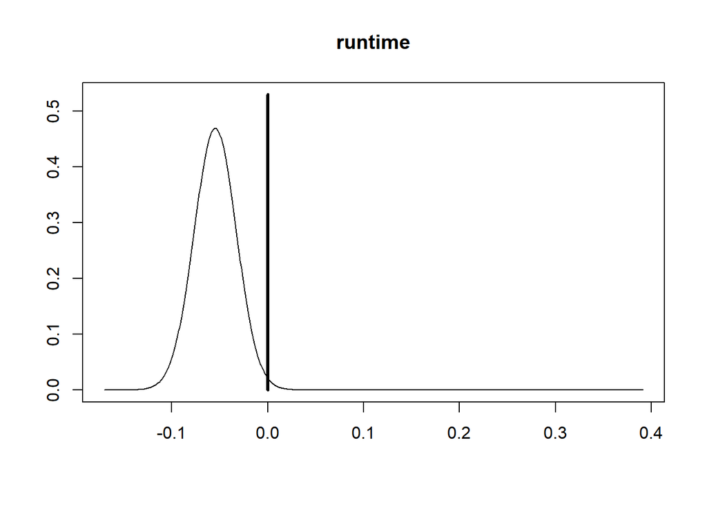

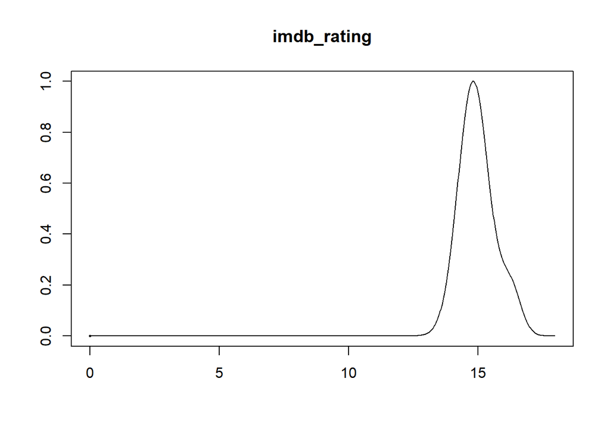

```r
# `runtime` is the 4th variable, while `imdb_rating` is the 9th variable in the data set
plot(coef_lscore, subset = c(4,9), ask = FALSE)
```

As can be seen from the above figure, the vertical bar in each of the posterior distributions plotted represents the posterior probability that the corresponding coefficient is $0$ while the bell shaped curve represents the density of plausible values from all the models where the coefficient is non-zero. Since `imdb_rating` is always included (with posterior model inclusion probability 1), there is no vertical bar in the distribution corresponding to `imdb_rating`, whereas `runtime` may not be included with a probability around $0.5$.

We can also provide $95\%$ credible intervals for these coefficients, as done with the below code snippet.

```r
confint(coef_lscore)
```

```
##                              2.5%        97.5%          beta
## Intercept            6.156763e+01 6.311117e+01  6.234769e+01
## feature_filmyes     -1.268353e+00 0.000000e+00 -1.046908e-01
## dramayes             0.000000e+00 0.000000e+00  1.604413e-02
## runtime             -8.316904e-02 0.000000e+00 -2.567772e-02
## mpaa_rating_Ryes    -2.159019e+00 0.000000e+00 -3.036174e-01
## thtr_rel_year       -5.593967e-02 0.000000e+00 -4.532635e-03
## oscar_seasonyes     -9.626425e-01 5.401315e-04 -8.034940e-02
## summer_seasonyes     0.000000e+00 9.687123e-01  8.704545e-02
## imdb_rating          1.369822e+01 1.656651e+01  1.498203e+01
## imdb_num_votes      -1.914428e-07 1.487472e-06  2.080713e-07
## critics_score        0.000000e+00 1.050106e-01  6.296648e-02
## best_pic_nomyes     -8.510866e-03 4.895298e+00  5.068035e-01
## best_pic_winyes      0.000000e+00 0.000000e+00 -8.502836e-03
## best_actor_winyes   -2.605628e+00 1.328689e-03 -2.876695e-01
## best_actress_winyes -2.802588e+00 0.000000e+00 -3.088382e-01
## best_dir_winyes     -1.147412e+00 9.965844e-03 -1.195011e-01
## top200_boxyes        0.000000e+00 0.000000e+00  8.648185e-02
## attr(,"Probability")
## [1] 0.95
## attr(,"class")
## [1] "confint.bas"
```

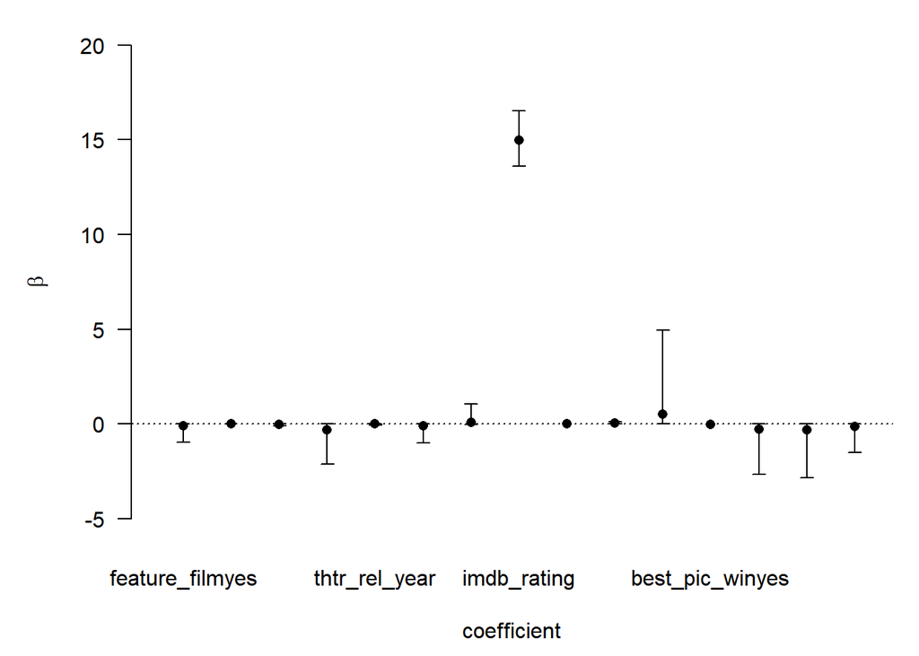

```r
plot(confint(coef_lscore, parm = 2:16))
```

using the `parm` argument to select which coefficients to plot (the intercept is parm=1).

For estimation under selection, `BAS` supports additional arguments via estimator. The default is `estimator="BMA"` which uses all models or `n.models`. Other options include estimation under the highest probability model (*HPM*) or median probability model (*MPM*).

#### Diagnostics

Now, let’s try *Zellner-Siow Cauchy* (`ZS-null` prior) on the coefficients and use Markov Chain Monte Carlo (`MCMC`) to compute posterior inclusion probabilities.

```r
bas_zs =  bas.lm(audience_score ~ .,
                   data=movies_no_na,
                   initprobs = "eplogp",
                   prior="ZS-null",
                   modelprior=uniform(),
                  method = "MCMC")

summary(bas_zs)
```

```
##                     P(B != 0 | Y)  model 1     model 2     model 3     model 4
## Intercept              1.00000000   1.0000   1.0000000   1.0000000   1.0000000
## feature_filmyes        0.06687241   0.0000   0.0000000   0.0000000   0.0000000
## dramayes               0.04476471   0.0000   0.0000000   0.0000000   0.0000000
## runtime                0.46638260   0.0000   1.0000000   0.0000000   0.0000000
## mpaa_rating_Ryes       0.20160141   0.0000   0.0000000   0.0000000   1.0000000
## thtr_rel_year          0.09432144   0.0000   0.0000000   0.0000000   0.0000000
## oscar_seasonyes        0.07767258   0.0000   0.0000000   0.0000000   0.0000000
## summer_seasonyes       0.08185196   0.0000   0.0000000   0.0000000   0.0000000
## imdb_rating            0.99999695   1.0000   1.0000000   1.0000000   1.0000000
## imdb_num_votes         0.06101151   0.0000   0.0000000   0.0000000   0.0000000
## critics_score          0.87848129   1.0000   1.0000000   1.0000000   1.0000000
## best_pic_nomyes        0.13541107   0.0000   0.0000000   0.0000000   0.0000000
## best_pic_winyes        0.04115677   0.0000   0.0000000   0.0000000   0.0000000
## best_actor_winyes      0.14542007   0.0000   0.0000000   1.0000000   0.0000000
## best_actress_winyes    0.14249039   0.0000   0.0000000   0.0000000   0.0000000
## best_dir_winyes        0.06997147   0.0000   0.0000000   0.0000000   0.0000000
## top200_boxyes          0.04812775   0.0000   0.0000000   0.0000000   0.0000000
## BF                             NA   1.0000   0.8702806   0.2236679   0.2217602
## PostProbs                      NA   0.1379   0.1235000   0.0304000   0.0303000
## R2                             NA   0.7525   0.7549000   0.7539000   0.7539000
## dim                            NA   3.0000   4.0000000   4.0000000   4.0000000
## logmarg                        NA 443.9495 443.8105657 442.4519125 442.4433468
##                         model 5
## Intercept             1.0000000
## feature_filmyes       0.0000000
## dramayes              0.0000000
## runtime               1.0000000
## mpaa_rating_Ryes      1.0000000
## thtr_rel_year         0.0000000
## oscar_seasonyes       0.0000000
## summer_seasonyes      0.0000000
## imdb_rating           1.0000000
## imdb_num_votes        0.0000000
## critics_score         1.0000000
## best_pic_nomyes       0.0000000
## best_pic_winyes       0.0000000
## best_actor_winyes     0.0000000
## best_actress_winyes   0.0000000
## best_dir_winyes       0.0000000
## top200_boxyes         0.0000000
## BF                    0.2055844
## PostProbs             0.0293000
## R2                    0.7563000
## dim                   5.0000000
## logmarg             442.3676066
```

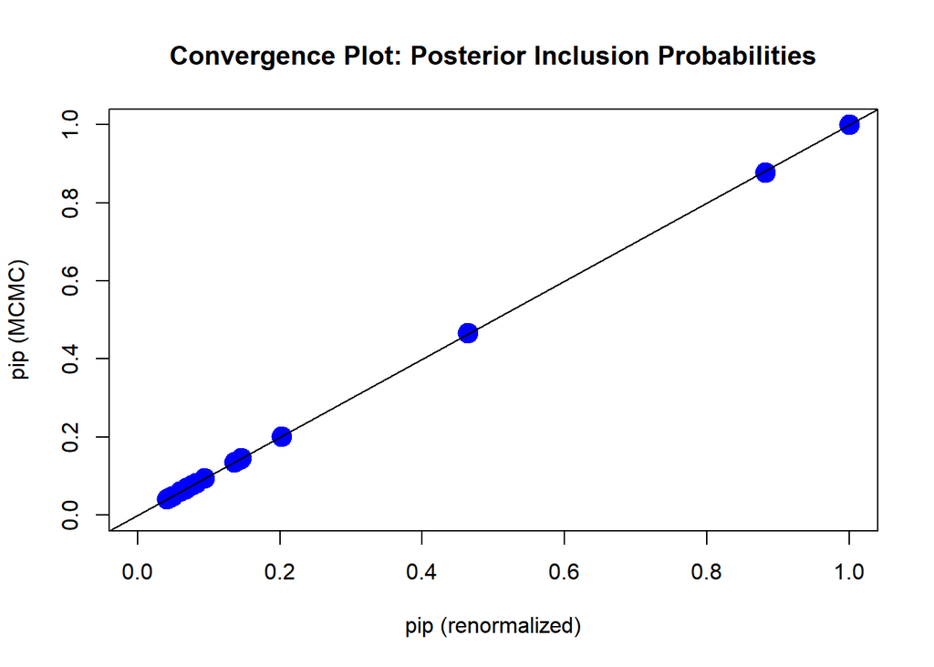

```r
diagnostics(bas_zs, type="pip", col = "blue", pch = 19, cex = 2)
```

- Convergence: Let’s check whether the MCMC (performed for this model selection) ran long enough and converged. Diagnostics function is used to ensure that most points stay in the $45^o$ diagonal line. The above convergence plot shows that all points fall within the $45^o$ diagonal line, suggesting that the posterior inclusion probability (pip) for each variable from *MCMC* has converged to the theoretical posterior inclusion probability.

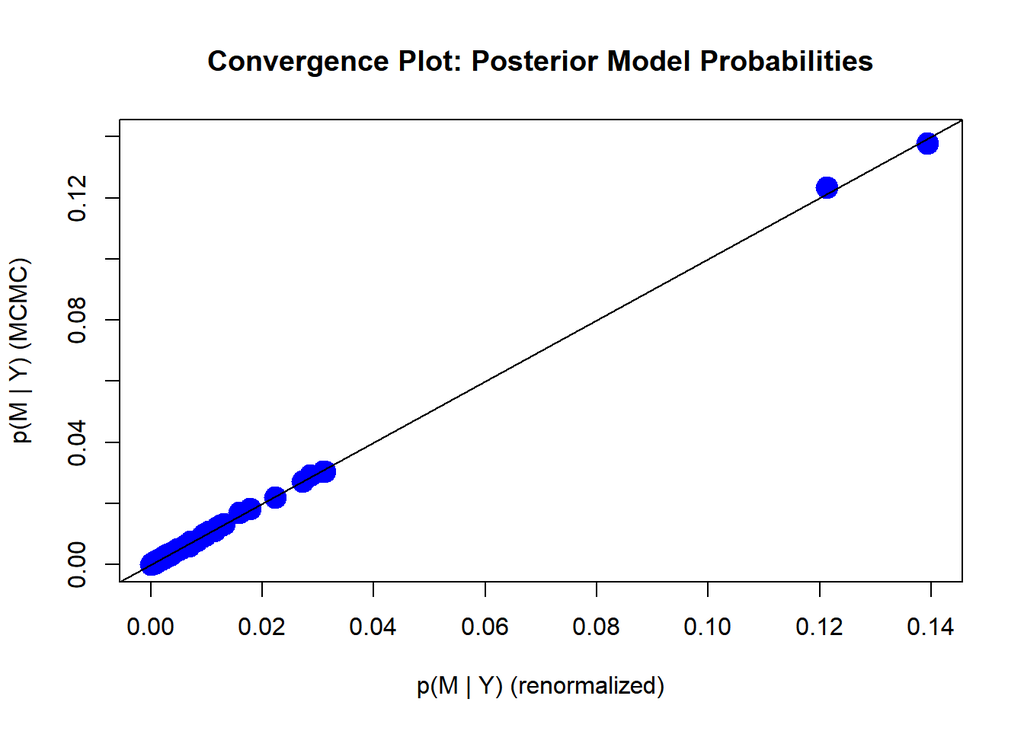

```r
diagnostics(bas_zs, type = "model", col = "blue", pch = 19, cex = 2)
```

From the above figure, We can see that all of the points lie on the $45^o$ line, validating the convergence of the posterior probabilities for the models given the filtration of all the observed data.

- Residuals vs. Fitted Values: The Residuals plot does not display a random scatter around 0, with non-constant variance across the data.

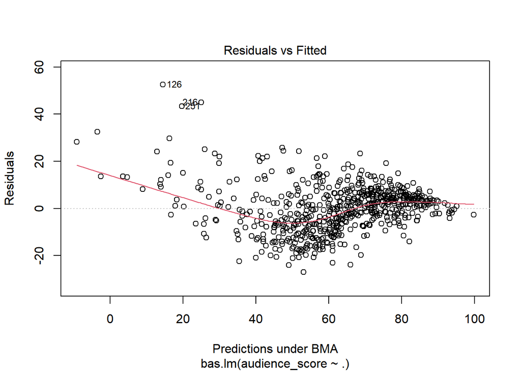

```r
plot(bas_zs, which = 1)
```

As seen from the figure above, for most of the fitted values, the residuals are centered around $0$, and the model appears to show a decrease in residual variance at is higher predicted values. This suggests that the model is likely to perform better prediction at higher audience scores. However, for fitted values that are less than $40$, the model tends to underestimate the `audience`score`s of the movies with high variance. The figure also shows $3$ possible outliers detected in this region.

- Model Probabilities: As can be seen from the next figure, the model probabilities starts to level off after $2000$ trials with `MCMC`, as each additional model does not contribute to an increase in cumulative probability. The search stops at $6000$, instead of enumerations of $2^16$ possible models, as done earlier with `BIC` prior on the coefficients.

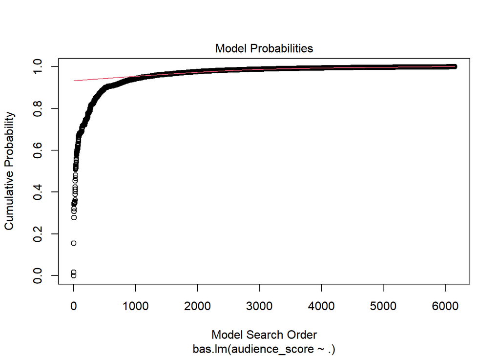

```r
  plot(bas_zs, which = 2)
```

- Model Complexity: The next figure shows that the models with highest *Bayes Factors* / *marginal likelihood* have around $3$ or $4$ predictors.

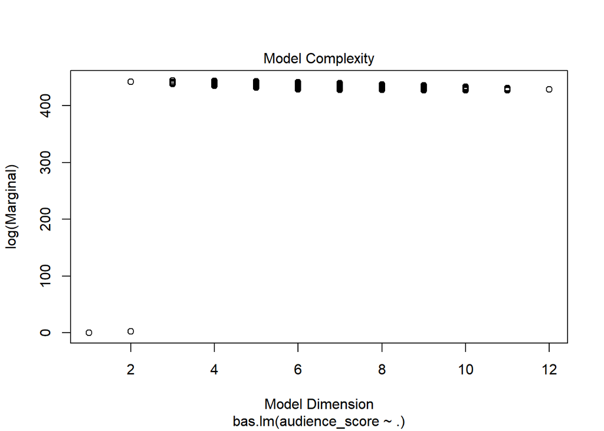

```r
plot(bas_zs, which = 3)
```

* Marginal Inclusion Probabilities: The lines in red correspond to the variables where the posterior inclusion probability (pip) is greater than $0.5$, suggesting that these variables (e.g., `imdb_rating`, `critics_score`) are important predictors for the response audience score.

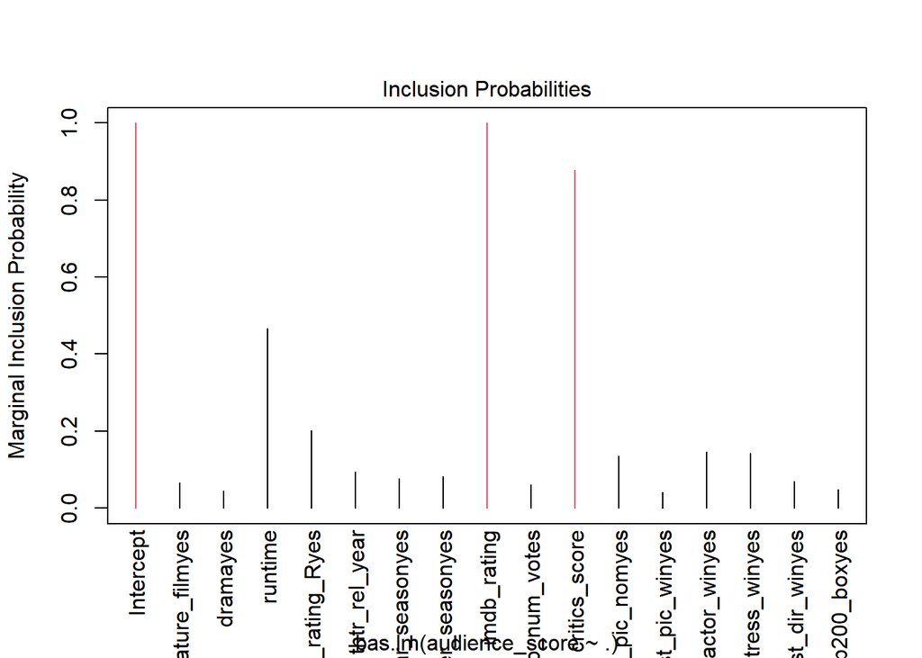

```r
plot(bas_zs, which = 4, ask=F)
```

## Part 5: Prediction

(5 points) Pick a movie from 2016 (a new movie that is not in the sample) and do a prediction for this movie using your the model you developed and the `predict` function in R.

The new movie (not yet observed / not present in the training sample) that we shall use for prediction is *Moonlight (2016)* (note that the ground-truth audience score for this movie is $79$). Let’s first create the data which we shall use for prediction using th following code snippet. The below links are the references for where the data for this movie comes from:

1. https://www.imdb.com/search/title/?year=2016,2016&sort=num_votes,desc
2. https://www.rottentomatoes.com/m/moonlight_2016
3. https://editorial.rottentomatoes.com/article/chicago-film-critics-2016-winners-announced/
4. https://en.wikipedia.org/wiki/Moonlight_(2016_film)
5. https://www.boxofficemojo.com/release/rl2558428673/rankings/?ref_=bo_rl_tab#tabs

```r
moonlight <- data.frame(feature_film='yes', drama='yes', runtime=111, mpaa_rating_R='yes',
                        thtr_rel_year=2016, oscar_season='yes', summer_season='no',
                        imdb_rating=7.4, imdb_num_votes=305195, critics_score=98,
                        best_pic_nom='yes', best_pic_win='yes', best_actor_win='yes',
                        best_actress_win='no', best_dir_win='no', top200_box='yes',
                        audience_score=79)
newdata <- moonlight[-length(moonlight)]
newdata
```

```
##   feature_film drama runtime mpaa_rating_R thtr_rel_year oscar_season
## 1          yes   yes     111           yes          2016          yes
##   summer_season imdb_rating imdb_num_votes critics_score best_pic_nom
## 1            no         7.4         305195            98          yes
##   best_pic_win best_actor_win best_actress_win best_dir_win top200_box
## 1          yes            yes               no           no        yes
```

```r
#movies_no_na[movies_no_na$best_pic_win=='yes', c('best_pic_win','best_pic_nom')]
#names(movies_no_na)
```

Now, we shall aim to predict the audience score for this new movie using the model fitted above. Simulation is used in `BAS` to construct predictive intervals with **Bayesian Model averaging**, while exact inference is often possible with predictive intervals under model selection. `BAS` has methods defined to return fitted values, fitted, using the observed design matrix and predictions at either the observed data or potentially new values, predict, as with `lm`.

Let’s use the `predict()` function to obtain the prediction for the audience score for the new movie first under model averaging and then compute a $95\%$ prediction interval for the audience score with covariates at the levels of the individual specified by opt, using the following code snippet.

```r
BMA_pred_bma_lscore <- predict(bma_lscore, newdata=newdata, estimator = "BMA", se.fit = TRUE)
ci_BMA_lscore <- confint(BMA_pred_bma_lscore, estimator = "BMA")
opt_BMA <- which.max(BMA_pred_bma_lscore$fit)
ci_BMA_lscore[opt_BMA, ]
```

```
##     2.5%    97.5%     pred
## 57.96060 97.86020 78.46105
```

Let’s find predicted values under the best predictive model, the one that has predictions closest to *BMA* and corresponding posterior standard deviations.

```r
BPM_pred_bma_lscore =  predict(bma_lscore, newdata=newdata, estimator="BPM", se.fit=TRUE)
variable.names(BPM_pred_bma_lscore)
```

```
##  [1] "Intercept"           "feature_filmyes"     "dramayes"
##  [4] "runtime"             "thtr_rel_year"       "oscar_seasonyes"
##  [7] "summer_seasonyes"    "imdb_rating"         "imdb_num_votes"
## [10] "best_actress_winyes" "best_dir_winyes"     "top200_boxyes"
```

```r
BPM_pred_bma_lscore$namesx[BPM_pred_bma_lscore$bestmodel+1]
```

```r
opt_BPM = which.max(BPM_pred_bma_lscore$fit)
ci_BPM_lscore = confint(BPM_pred_bma_lscore, parm="pred")
ci_BPM_lscore[opt_BPM,]
```

```
##     2.5%    97.5%     pred
## 57.91828 99.00386 78.46107
```

In the code above, the function `variable.names()` can be used to extract the names of all of the predictors in the Best Probability model. This can be used to identify the variables in the Highest Probability Model (*HPM*).

```r
HPM_pred_bma_lscore =  predict(bma_lscore, newdata=newdata, estimator="HPM", se.fit=TRUE)
variable.names(HPM_pred_bma_lscore)
```

```
## [1] "Intercept"     "runtime"       "imdb_rating"   "critics_score"
```

```r
HPM_pred_bma_lscore$namesx[HPM_pred_bma_lscore$bestmodel+1]
```

```r
opt_HPM = which.max(HPM_pred_bma_lscore$fit)
ci_HPM_lscore = confint(HPM_pred_bma_lscore, parm="pred")
ci_HPM_lscore[opt_HPM,]
```

```
##     2.5%    97.5%     pred
## 58.75375 98.28249 78.51812
```

We can compare this to the Highest probability model that we found earlier and the Median Probability Model (MPM).

```r
MPM_pred_bma_lscore =  predict(bma_lscore, newdata=newdata, estimator="MPM", se.fit=TRUE)
variable.names(MPM_pred_bma_lscore)
```

```
## [1] "Intercept"     "imdb_rating"   "critics_score"
```

```r
MPM_pred_bma_lscore$namesx[MPM_pred_bma_lscore$bestmodel+1]
```

```r
opt_MPM = which.max(MPM_pred_bma_lscore$fit)
ci_MPM_lscore = confint(MPM_pred_bma_lscore, parm="pred")
ci_MPM_lscore[opt_MPM,]
```

```
##     2.5%    97.5%     pred
## 58.77803 98.47299 78.62551
```

Based on these results, the covariate `imdb_rating` is included in all of the following models: the best predictive model, the median probability model, and the highest posterior probability model. Finally, let’s compare the predictions by different models with the actual audience score for the movie.

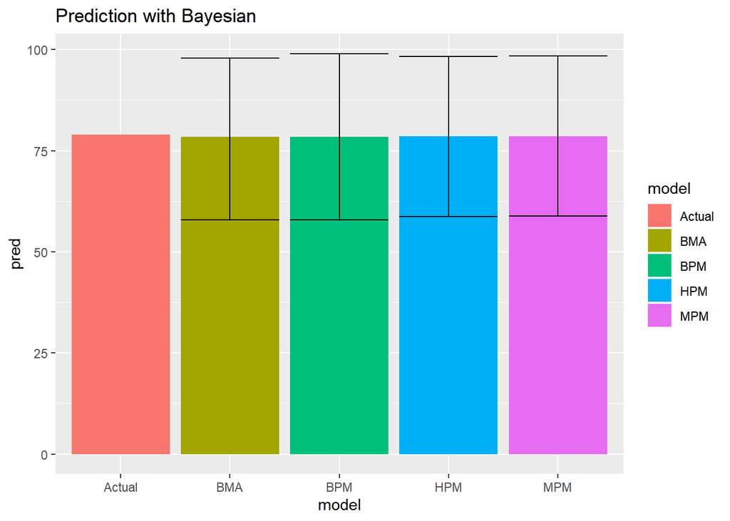

```r
pred_df <- NULL
pred_df <- rbind(pred_df, ci_BPM_lscore[opt_BPM,])
pred_df <- rbind(pred_df, ci_MPM_lscore[opt_MPM,])
pred_df <- rbind(pred_df, ci_HPM_lscore[opt_HPM,])
pred_df <- rbind(pred_df, ci_BMA_lscore[opt_BMA,])
pred_df <- as.data.frame(pred_df)
pred_df$model <- c('BPM', 'MPM', 'HPM', 'BMA')
names(pred_df)[1:2] <- c('LCL', 'UCL')
pred_df <- rbind(pred_df, data.frame(LCL=NA, UCL=NA, pred=moonlight$audience_score, model='Actual'))
ggplot(data = pred_df) +
  geom_bar(stat = "identity", aes(x = model, y = pred, fill=model)) +
  geom_errorbar(
    aes(x=model,
        ymin = LCL,
        ymax = UCL), color = 1
  ) + ggtitle('Prediction with Bayesian')
```

As can be seen from the above plot, the actual (ground-truth) audience score is very close to the ones predicted by different models and always inside the $95\%$ credible intervals.

## Part 6: Conclusion

(3 points) A brief summary of your findings from the previous sections without repeating your statements from earlier as well as a discussion of what you have learned about the data and your research question. You should also discuss any shortcomings of your current study (either due to data collection or methodology) and include ideas for possible future research.

#### Findings

- The predictor variables that were included in top models with highest posterior probability (using *BMA*) are `runtime`, `imdb_rating`, `critics_score`, `thtr_rel_year` and the new variables added e.g., whether `mpaa_rating` is `R`, `best_actor_win` is `yes` etc., in order to predict the response `audience_score`, using Bayesian linear regression with `BAS`.
- The predictive models *BPM*, *HPM* and *MPM* preform quite well to predict the audience score of the unseen movie (with error $\approx 0.5$), *MPM* performed the best (with lowest error) on the unseen movie.

#### Shortcomings

- Model evaluation need to be done properly on a larger unseen test dataset to quantify the performance of the models (e.g., with metrics such as `RMSE` or `MAE`), we have tested the models only on a single unseen example.
- The model’s residuals plot displays a wave pattern which suggests high varying predictive ability, particularly at lower scores, where it’s likely to underestimate the actual score.
- The movies dataset is pretty dynamic and ever-changing because the ratings, votes can keep on changing over time. In order to cope with it, we may need to train the model with newer data in a while by choosing random samples from the movies released in later yers, for the models to be able to better generalize to unseen data (use time series models?).

#### Future Research

- To address the shortcomings, we may want to have a separate held-out validation dataset for model selection / tuning the hyper-parameters of the models to ensure proper model evaluation (e.g., with metrics such as `RMSE` or `MAE`).
- We need to add more samples (e.g., the movies released in later years and particularly the movies with low audience scores) and / or consider to add more features / predictor variables and rebuild the model.